# Tugas MPDW Zulfa

Zulfa Hafizhoh

2023-09-04

## Library / Packages

```r
#install.packages("forecast")
#install.packages("graphics")
#install.packages("TTR")
#install.packages("TSA")
```

```r
library("forecast")
```

```r
library("graphics")
library("TTR")
library("TSA")
```

## Impor Data

```r
library(rio)
data <- import("https://raw.githubusercontent.com/zulfah6/MPDW/main/Data/Data%20Inflasi.csv")
```

## Eksplorasi Data

```r
View(data)
str(data)
```

```
## 'data.frame':    160 obs. of  2 variables:
##  $ Periode: int  1 2 3 4 5 6 7 8 9 10 ...
##  $ Inflasi: num  3.72 3.81 3.43 3.91 4.16 5.05 6.22 6.44 5.8 5.67 ...
```

```r
dim(data)
```

```
## [1] 160   2
```

Mengubah data agar terbaca sebagai data deret waktu dengan fungsi `ts()` .

```r
data.ts <- ts(data$`Inflasi`)
```

Menampilkan ringkasan data

```r
summary(data.ts)
```

```
##    Min. 1st Qu.  Median    Mean 3rd Qu.    Max.
##   1.320   3.152   3.980   4.319   5.548   8.790
```

Membuat plot data deret waktu

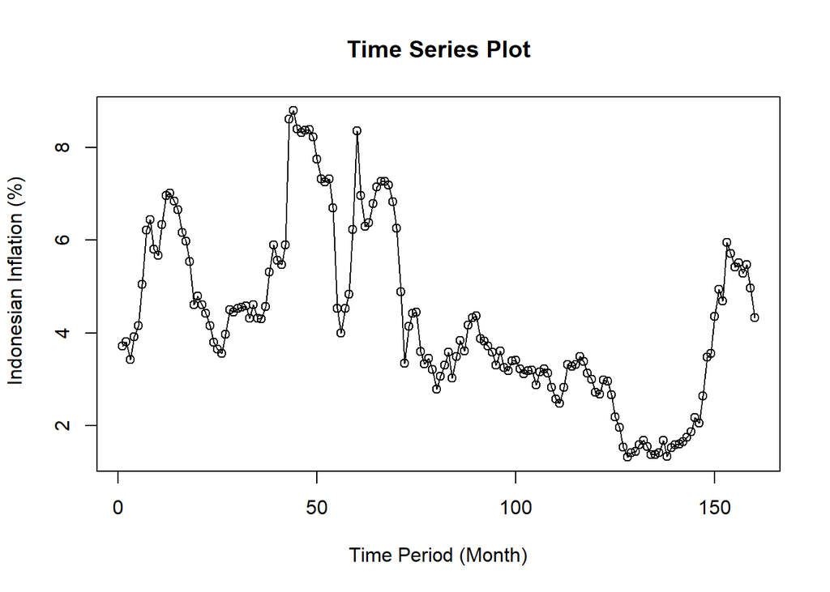

```r
ts.plot(data.ts, xlab="Time Period (Month)", ylab=" Indonesian Inflation (%)",
        main = "Time Series Plot")
points(data.ts)
```

Menyimpan plot

```r
#menyimpan plot
#dev.copy(png, "eksplorasi.png")
#dev.off()
```

## Single Moving Average

### Pembagian Data

```r
#membagi data latih dan data uji
training_ma <- data[1:128,]
testing_ma <- data[129:160,]
train_ma.ts <- ts(training_ma$`Inflasi`)
test_ma.ts <- ts(testing_ma$`Inflasi`)
```

### Eksplorasi Data

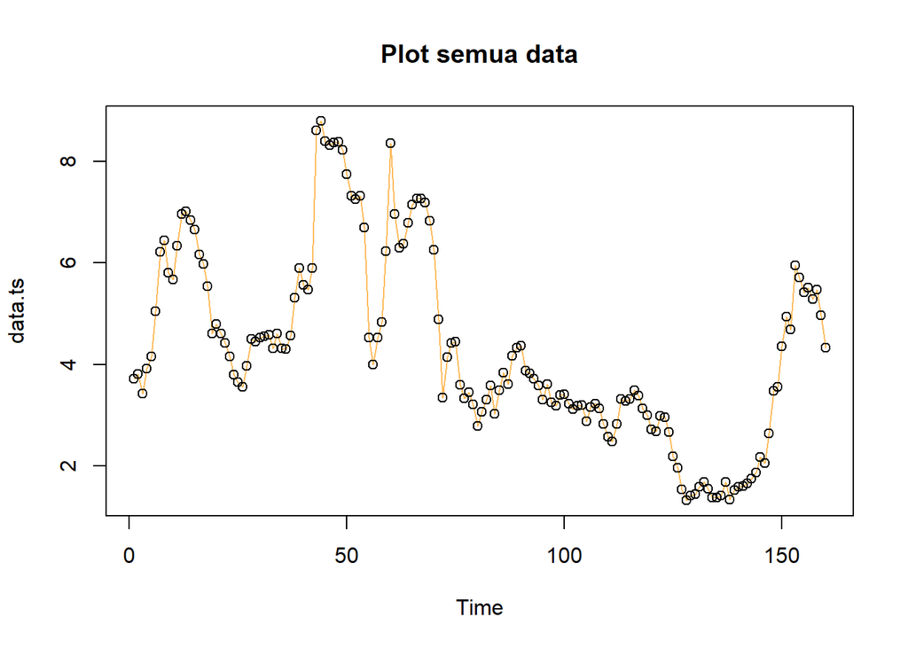

```r
#eksplorasi keseluruhan data
plot(data.ts, col="#FFBB5C",main="Plot semua data")
points(data.ts)
```

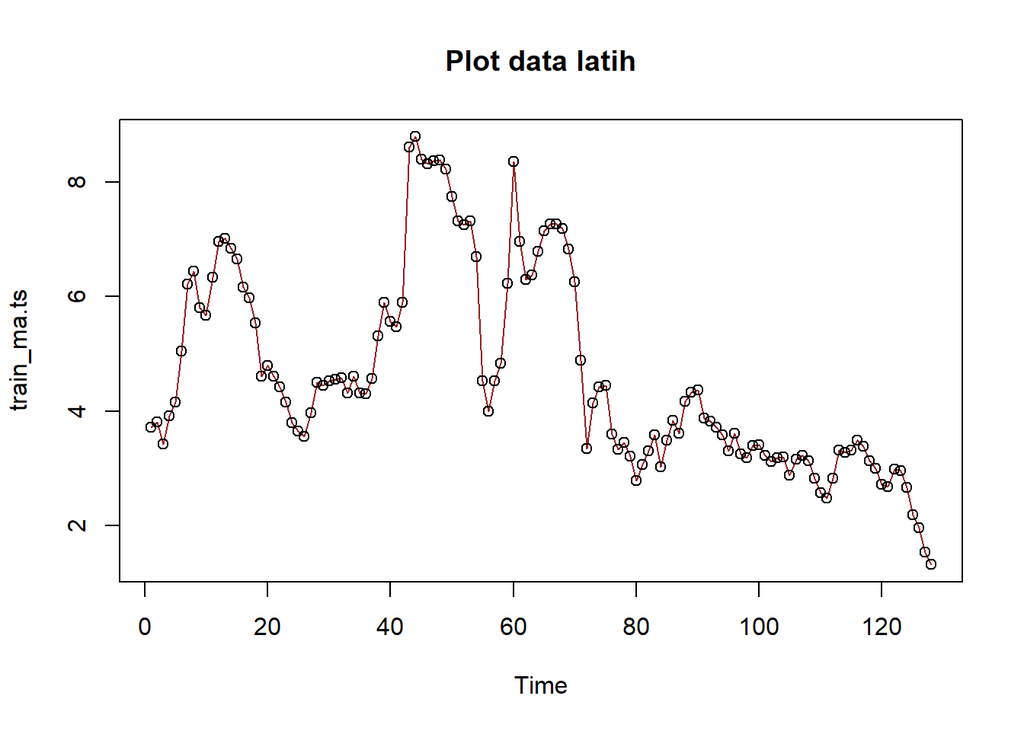

```r
#eksplorasi data latih
plot(train_ma.ts, col="#952323",main="Plot data latih")
points(train_ma.ts)
```

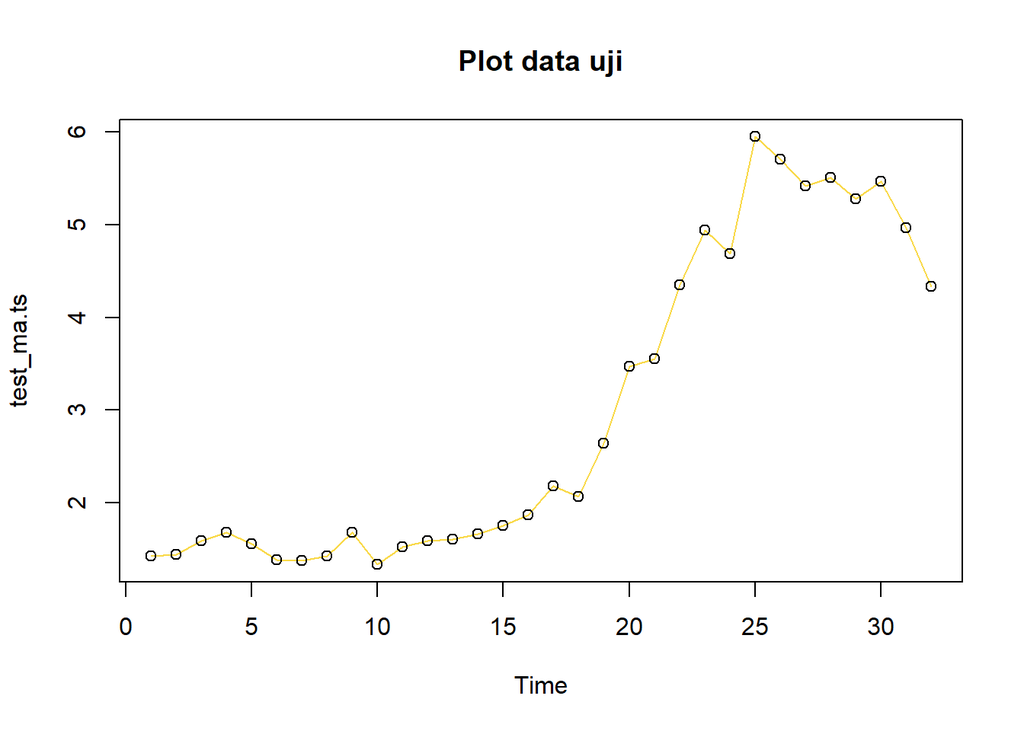

```r
#eksplorasi data uji
plot(test_ma.ts, col="#F9D949",main="Plot data uji")
points(test_ma.ts)
```

Eksplorasi data juga dapat dilakukan menggunakan package `ggplot2` dengan terlebih dahulu memanggil library *package* `ggplot2`.

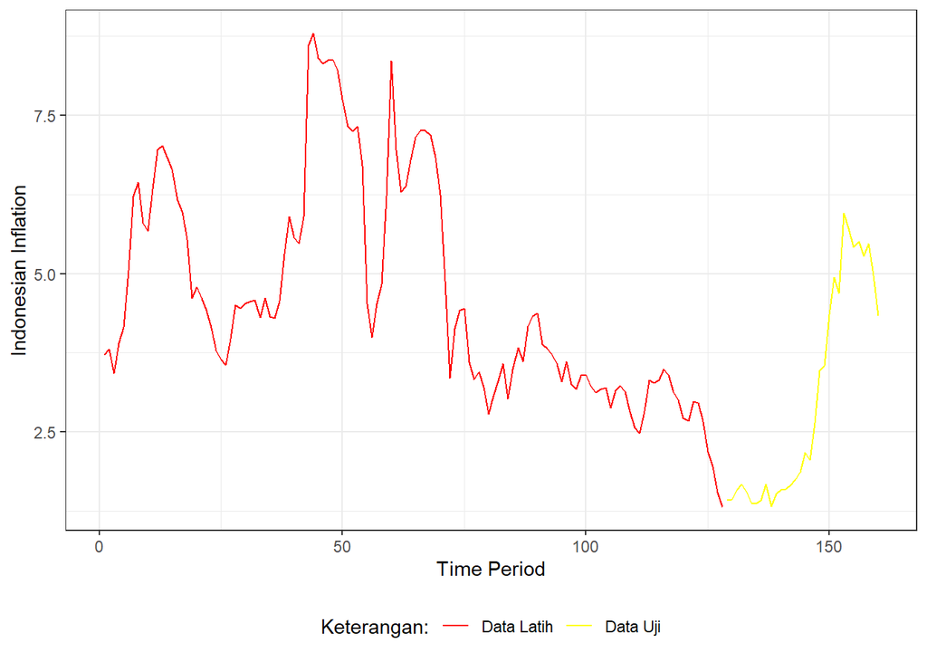

```r
#Eksplorasi dengan GGPLOT
library(ggplot2)
ggplot() +
  geom_line(data = training_ma, aes(x = Periode, y = Inflasi, col = "Data Latih")) +
  geom_line(data = testing_ma, aes(x = Periode , y = Inflasi, col = "Data Uji")) +
  labs(x = "Time Period", y = "Indonesian Inflation", color = "Legend") +
  scale_colour_manual(name="Keterangan:", breaks = c("Data Latih", "Data Uji"),
                      values = c("red", "yellow")) +
  theme_bw() + theme(legend.position = "bottom",
                     plot.caption = element_text(hjust=0.5, size=12))
```

### Single Moving Average (SMA)

Ide dasar dari Single Moving Average (SMA) adalah data suatu periode dipengaruhi oleh data periode sebelumnya. Metode pemulusan ini cocok digunakan untuk pola data stasioner atau konstan. Prinsip dasar metode pemulusan ini adalah data pemulusan pada periode ke-t merupakan rata rata dari m buah data pada periode ke-t hingga periode ke (t-m+1). Data pemulusan pada periode ke-t selanjutnya digunakan sebagai nilai peramalan pada periode ke t+1

Pemulusan menggunakan metode SMA dilakukan dengan fungsi `SMA()`. Dalam hal ini akan dilakukan pemulusan dengan parameter `m=2`.

```r
data.sma<-SMA(train_ma.ts, n=2)
data.sma
```

```
## Time Series:
## Start = 1
## End = 128
## Frequency = 1
##   [1]    NA 3.765 3.620 3.670 4.035 4.605 5.635 6.330 6.120 5.735 6.000 6.645
##  [13] 6.990 6.930 6.745 6.405 6.070 5.760 5.075 4.700 4.700 4.515 4.285 3.970
##  [25] 3.720 3.605 3.765 4.235 4.475 4.490 4.545 4.570 4.445 4.460 4.465 4.310
##  [37] 4.435 4.940 5.605 5.735 5.520 5.685 7.255 8.700 8.595 8.360 8.345 8.375
##  [49] 8.300 7.985 7.535 7.285 7.285 7.010 5.615 4.260 4.260 4.680 5.530 7.295
##  [61] 7.660 6.625 6.335 6.585 6.970 7.205 7.260 7.220 7.005 6.540 5.570 4.120
##  [73] 3.745 4.280 4.435 4.025 3.465 3.390 3.330 3.000 2.930 3.190 3.445 3.300
##  [85] 3.255 3.660 3.720 3.890 4.250 4.350 4.125 3.850 3.770 3.650 3.440 3.455
##  [97] 3.430 3.215 3.290 3.405 3.320 3.175 3.150 3.190 3.040 3.020 3.195 3.180
## [109] 2.975 2.695 2.525 2.655 3.075 3.300 3.300 3.405 3.440 3.260 3.065 2.860
## [121] 2.700 2.830 2.970 2.815 2.430 2.075 1.750 1.430
```

Data pemulusan pada periode ke-t selanjutnya digunakan sebagai nilai peramalan pada periode ke t+1 sehingga hasil peramalan 1 periode kedepan adalah sebagai berikut.

```r
data.ramal<-c(NA,data.sma)
data.ramal #forecast 1 periode ke depan
```

```
##   [1]    NA    NA 3.765 3.620 3.670 4.035 4.605 5.635 6.330 6.120 5.735 6.000
##  [13] 6.645 6.990 6.930 6.745 6.405 6.070 5.760 5.075 4.700 4.700 4.515 4.285
##  [25] 3.970 3.720 3.605 3.765 4.235 4.475 4.490 4.545 4.570 4.445 4.460 4.465
##  [37] 4.310 4.435 4.940 5.605 5.735 5.520 5.685 7.255 8.700 8.595 8.360 8.345
##  [49] 8.375 8.300 7.985 7.535 7.285 7.285 7.010 5.615 4.260 4.260 4.680 5.530
##  [61] 7.295 7.660 6.625 6.335 6.585 6.970 7.205 7.260 7.220 7.005 6.540 5.570
##  [73] 4.120 3.745 4.280 4.435 4.025 3.465 3.390 3.330 3.000 2.930 3.190 3.445
##  [85] 3.300 3.255 3.660 3.720 3.890 4.250 4.350 4.125 3.850 3.770 3.650 3.440
##  [97] 3.455 3.430 3.215 3.290 3.405 3.320 3.175 3.150 3.190 3.040 3.020 3.195
## [109] 3.180 2.975 2.695 2.525 2.655 3.075 3.300 3.300 3.405 3.440 3.260 3.065
## [121] 2.860 2.700 2.830 2.970 2.815 2.430 2.075 1.750 1.430
```

Selanjutnya akan dilakukan peramalan sejumlah data uji yaitu 32 periode. Pada metode SMA, hasil peramalan 32 periode ke depan akan bernilai sama dengan hasil peramalan 1 periode kedepan. Dalam hal ini akan dilakukan pengguabungan data aktual train, data hasil pemulusan dan data hasil ramalan 32 periode kedepan.

```r
data.gab<-cbind(aktual=c(train_ma.ts,rep(NA,32)),pemulusan=c(data.sma,rep(NA,32)),ramalan=c(data.ramal,rep(data.ramal[length(data.ramal)],31)))
data.gab #forecast 32 periode ke depan
```

```
##        aktual pemulusan ramalan
##   [1,]   3.72        NA      NA
##   [2,]   3.81     3.765      NA
##   [3,]   3.43     3.620   3.765
##   [4,]   3.91     3.670   3.620
##   [5,]   4.16     4.035   3.670
##   [6,]   5.05     4.605   4.035
##   [7,]   6.22     5.635   4.605
##   [8,]   6.44     6.330   5.635
##   [9,]   5.80     6.120   6.330
##  [10,]   5.67     5.735   6.120
##  [11,]   6.33     6.000   5.735
##  [12,]   6.96     6.645   6.000
##  [13,]   7.02     6.990   6.645
##  [14,]   6.84     6.930   6.990
```

[output cut: 146 more lines]

Adapun plot data deret waktu dari hasil peramalan yang dilakukan adalah sebagai berikut.

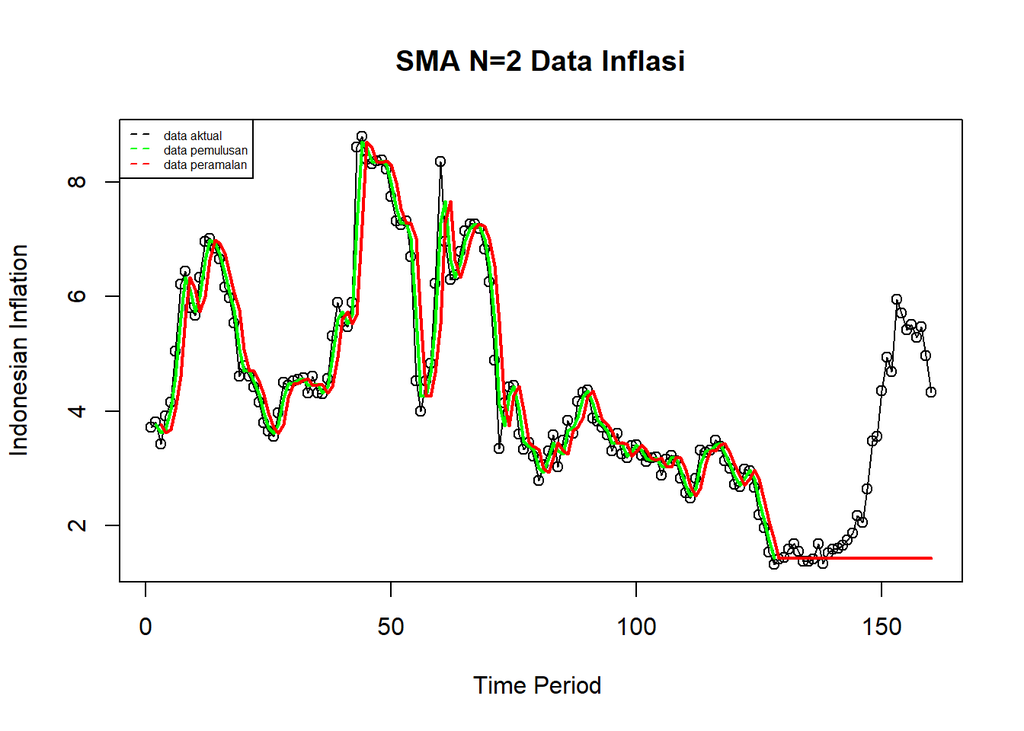

```r
ts.plot(data.ts, xlab="Time Period ", ylab="Indonesian Inflation", main= "SMA N=2 Data Inflasi")
points(data.ts)
lines(data.gab[,2],col="green",lwd=2)
lines(data.gab[,3],col="red",lwd=2)
legend("topleft",c("data aktual","data pemulusan","data peramalan"), lty=8, col=c("black","green","red"), cex=0.5)
```

Selanjutnya perhitungan akurasi dilakukan dengan ukuran akurasi *Sum Squares Error* (SSE), *Mean Square Error* (MSE) dan *Mean Absolute Percentage Error* (MAPE). Perhitungan akurasi dilakukan baik pada data latih maupun pada data uji.

```r
#Menghitung nilai keakuratan data latih
error_train.sma = train_ma.ts-data.ramal[1:length(train_ma.ts)]
SSE_train.sma = sum(error_train.sma[5:length(train_ma.ts)]^2)
MSE_train.sma = mean(error_train.sma[5:length(train_ma.ts)]^2)
MAPE_train.sma = mean(abs((error_train.sma[5:length(train_ma.ts)]/train_ma.ts[5:length(train_ma.ts)])*100))

akurasi_train.sma <- matrix(c(SSE_train.sma, MSE_train.sma, MAPE_train.sma))
row.names(akurasi_train.sma)<- c("SSE", "MSE", "MAPE")
colnames(akurasi_train.sma) <- c("Akurasi m = 2")
akurasi_train.sma
```

```
##      Akurasi m = 2
## SSE     61.7744250
## MSE      0.4981808
## MAPE    10.4465670
```

```r
#Menghitung nilai keakuratan data uji
error_test.sma = test_ma.ts-data.gab[129:160,3]
SSE_test.sma = sum(error_test.sma^2)
MSE_test.sma = mean(error_test.sma^2)
MAPE_test.sma = mean(abs((error_test.sma/test_ma.ts*100)))

akurasi_test.sma <- matrix(c(SSE_test.sma, MSE_test.sma, MAPE_test.sma))
row.names(akurasi_test.sma)<- c("SSE", "MSE", "MAPE")
colnames(akurasi_test.sma) <- c("Akurasi m = 2")
akurasi_test.sma
```

```
##      Akurasi m = 2
## SSE     166.547500
## MSE       5.204609
## MAPE     36.501527
```

Mengubah data agar terbaca sebagai data deret waktu dengan fungsi `ts()`

```r
data.ts <- ts(data$Inflasi)
data.ts
```

```
## Time Series:
## Start = 1
## End = 160
## Frequency = 1
##   [1] 3.72 3.81 3.43 3.91 4.16 5.05 6.22 6.44 5.80 5.67 6.33 6.96 7.02 6.84 6.65
##  [16] 6.16 5.98 5.54 4.61 4.79 4.61 4.42 4.15 3.79 3.65 3.56 3.97 4.50 4.45 4.53
##  [31] 4.56 4.58 4.31 4.61 4.32 4.30 4.57 5.31 5.90 5.57 5.47 5.90 8.61 8.79 8.40
##  [46] 8.32 8.37 8.38 8.22 7.75 7.32 7.25 7.32 6.70 4.53 3.99 4.53 4.83 6.23 8.36
##  [61] 6.96 6.29 6.38 6.79 7.15 7.26 7.26 7.18 6.83 6.25 4.89 3.35 4.14 4.42 4.45
##  [76] 3.60 3.33 3.45 3.21 2.79 3.07 3.31 3.58 3.02 3.49 3.83 3.61 4.17 4.33 4.37
##  [91] 3.88 3.82 3.72 3.58 3.30 3.61 3.25 3.18 3.40 3.41 3.23 3.12 3.18 3.20 2.88
## [106] 3.16 3.23 3.13 2.82 2.57 2.48 2.83 3.32 3.28 3.32 3.49 3.39 3.13 3.00 2.72
## [121] 2.68 2.98 2.96 2.67 2.19 1.96 1.54 1.32 1.42 1.44 1.59 1.68 1.55 1.38 1.37
## [136] 1.42 1.68 1.33 1.52 1.59 1.60 1.66 1.75 1.87 2.18 2.06 2.64 3.47 3.55 4.35
## [151] 4.94 4.69 5.95 5.71 5.42 5.51 5.28 5.47 4.97 4.33
```

```r
summary(data.ts)
```

```
##    Min. 1st Qu.  Median    Mean 3rd Qu.    Max.
##   1.320   3.152   3.980   4.319   5.548   8.790
```

Membuat plot data deret waktu

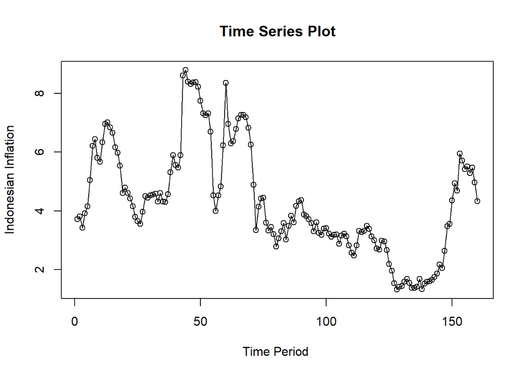

```r
ts.plot(data.ts, xlab="Time Period ", ylab="Indonesian Inflation",
        main = "Time Series Plot")
points(data.ts)
```

Pembagian Data

Pembagian data latih (training) dan data uji (testing) dilakukan dengan perbandingan 80% data latih dan 20% data uji.

```r
#membagi data latih dan data uji
training_data <- data[1:128,]
testing_data <- data[129:160,]
train_data.ts <- ts(training_data$Inflasi)
test_data.ts <- ts(testing_data$Inflasi)
```

## Single Exponential Smoothing

Metode *Exponential Smoothing* adalah metode pemulusan dengan melakukan pembobotan menurun secara eksponensial. Nilai yang lebih baru diberi bobot yang lebih besar dari nilai terdahulu. Terdapat satu atau lebih parameter pemulusan yang ditentukan secara eksplisit, dan hasil pemilihan parameter tersebut akan menentukan bobot yang akan diberikan pada nilai pengamatan. Ada dua macam model, yaitu model tunggal dan ganda. Eksplorasi Data

Eksplorasi data dilakukan pada keseluruhan data, data latih serta data uji menggunakan plot data deret waktu.

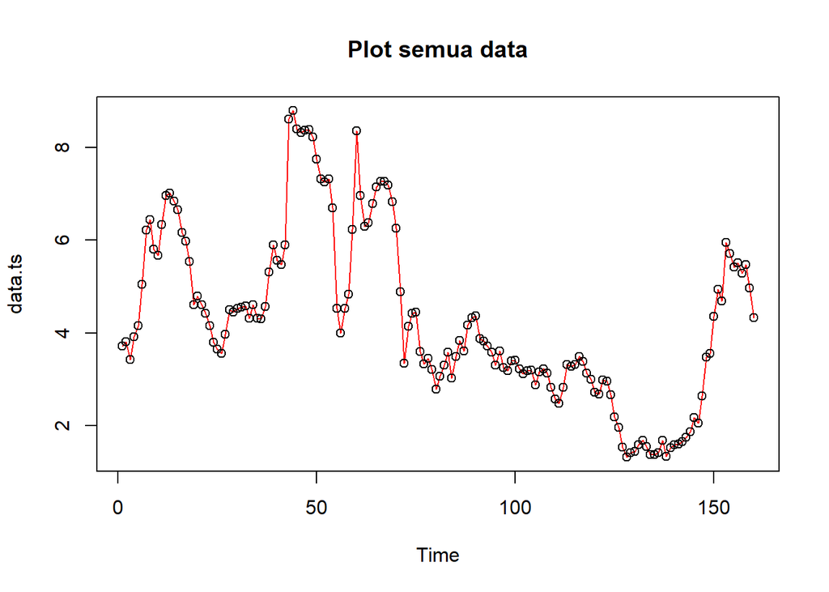

```r
#eksplorasi keseluruhan data
plot(data.ts, col="red",main="Plot semua data")
points(data.ts)
```

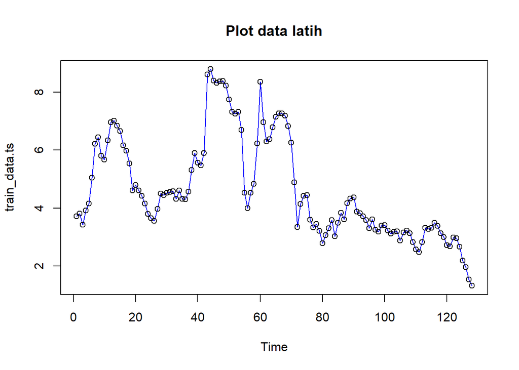

```r
#eksplorasi data latih
plot(train_data.ts, col="blue",main="Plot data latih")
points(train_data.ts)
```

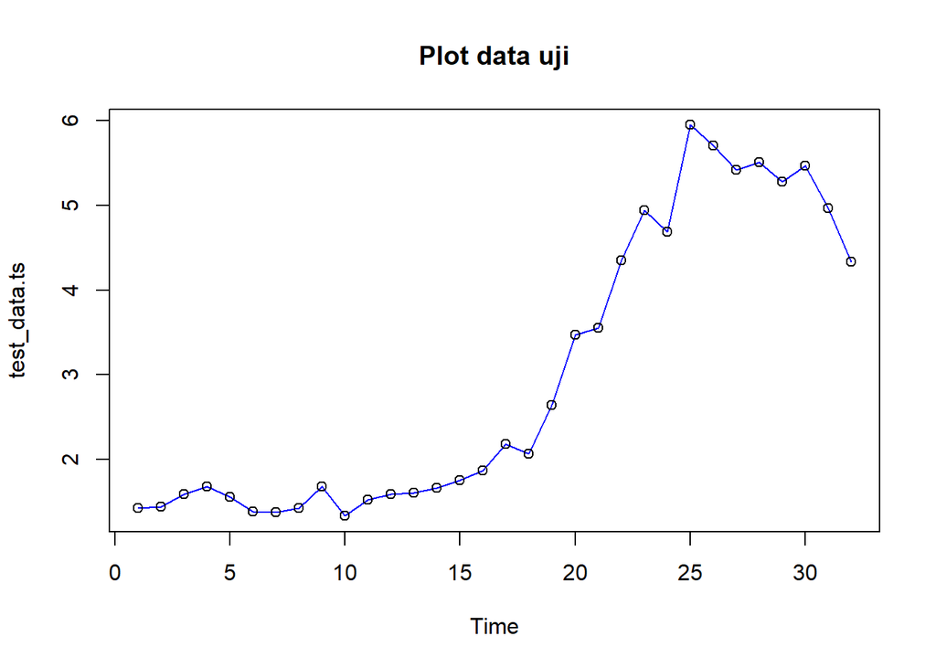

```r
#eksplorasi data uji
plot(test_data.ts, col="blue",main="Plot data uji")
points(test_data.ts)
```

###SES

Single Exponential Smoothing merupakan metode pemulusan yang tepat digunakan untuk data dengan pola stasioner atau konstan.

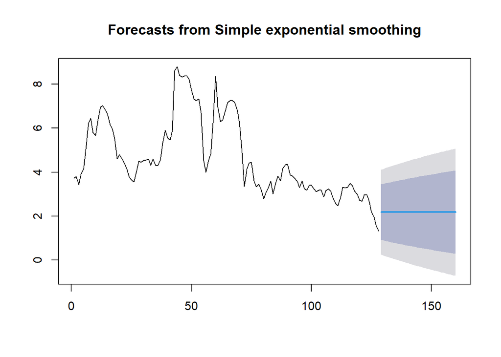

```r
#Cara 1 (fungsi ses)
ses.1 <- ses(train_data.ts, h = 32, alpha = 0.2)
plot(ses.1)
```

```r
ses.1
```

```
##     Point Forecast     Lo 80    Hi 80        Lo 95    Hi 95
## 129       2.182154 0.9181788 3.446130  0.249070504 4.115238
## 130       2.182154 0.8931471 3.471162  0.210787899 4.153521
## 131       2.182154 0.8685924 3.495716  0.173234686 4.191074
## 132       2.182154 0.8444883 3.519820  0.136370698 4.227938
## 133       2.182154 0.8208110 3.543498  0.100159326 4.264150
## 134       2.182154 0.7975385 3.566770  0.064567088 4.299742
## 135       2.182154 0.7746507 3.589658  0.029563273 4.334746
## 136       2.182154 0.7521292 3.612180 -0.004880372 4.369189
## 137       2.182154 0.7299570 3.634352 -0.038789911 4.403099
## 138       2.182154 0.7081182 3.656191 -0.072189444 4.436498
## 139       2.182154 0.6865983 3.677711 -0.105101314 4.469410
## 140       2.182154 0.6653837 3.698925 -0.137546279 4.501855
## 141       2.182154 0.6444617 3.719847 -0.169543662 4.533853
## 142       2.182154 0.6238206 3.740488 -0.201111491 4.565420
```

[output cut: 18 more lines]

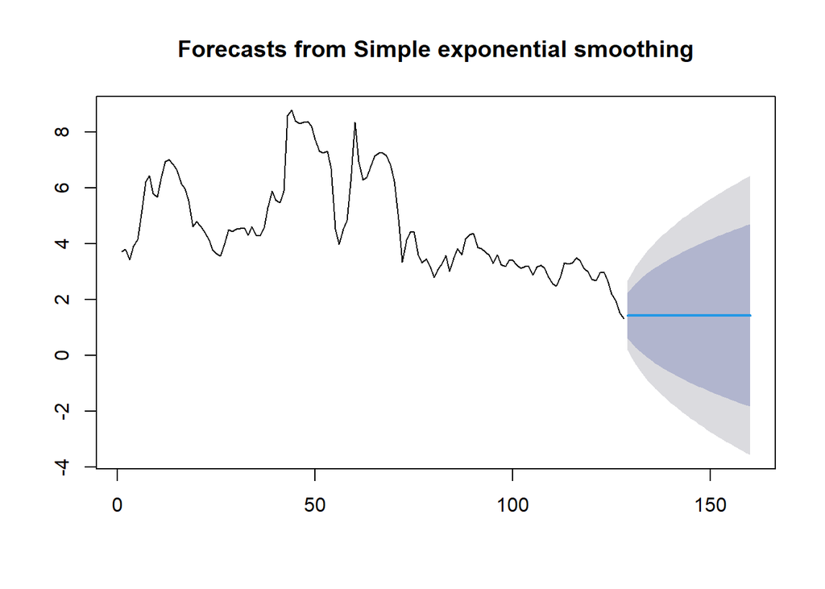

```r
ses.2<- ses(train_data.ts, h = 32, alpha = 0.7)
plot(ses.2)
```

```r
ses.2
```

```
##     Point Forecast       Lo 80    Hi 80       Lo 95    Hi 95
## 129       1.434561  0.62190785 2.247214  0.19171523 2.677407
## 130       1.434561  0.44259140 2.426531 -0.08252561 2.951648
## 131       1.434561  0.29105664 2.578065 -0.31427804 3.183400
## 132       1.434561  0.15737629 2.711746 -0.51872448 3.387847
## 133       1.434561  0.03641962 2.832702 -0.70371175 3.572834
## 134       1.434561 -0.07487528 2.943997 -0.87392261 3.743045
## 135       1.434561 -0.17850950 3.047632 -1.03241747 3.901540
## 136       1.434561 -0.27587607 3.144998 -1.18132680 4.050449
## 137       1.434561 -0.36799095 3.237113 -1.32220434 4.191326
## 138       1.434561 -0.45562208 3.324744 -1.45622460 4.325347
## 139       1.434561 -0.53936672 3.408489 -1.58430097 4.453423
## 140       1.434561 -0.61970023 3.488822 -1.70716047 4.576283
## 141       1.434561 -0.69700832 3.566130 -1.82539298 4.694515
## 142       1.434561 -0.77160905 3.640731 -1.93948497 4.808607
```

[output cut: 18 more lines]

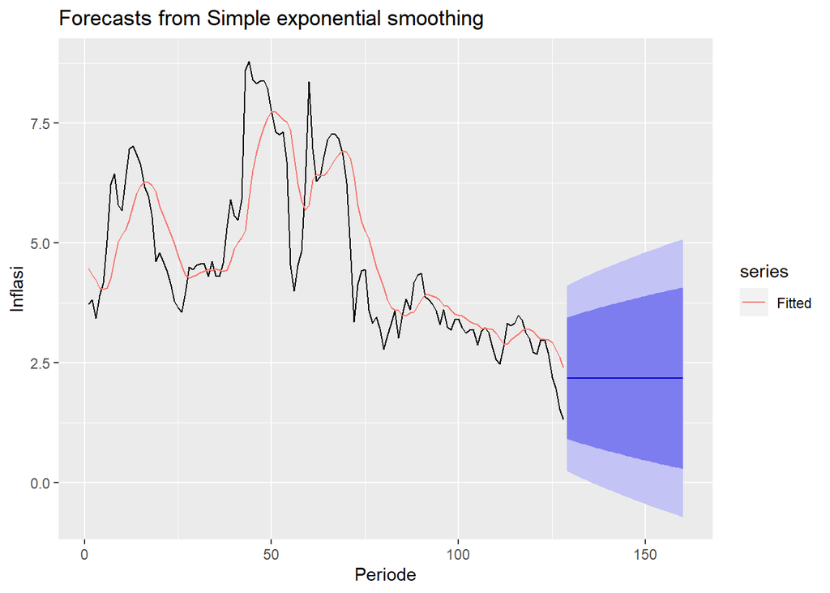

```r
autoplot(ses.1) +
  autolayer(fitted(ses.1), series="Fitted") +
  ylab("Inflasi") + xlab("Periode")
```

Pada fungsi ses() , terdapat beberapa argumen yang umum digunakan, yaitu nilai y , gamma , beta , alpha , dan h .

Nilai y adalah nilai data deret waktu, gamma adalah parameter pemulusan untuk komponen musiman, beta adalah parameter pemulusan untuk tren, dan alpha adalah parameter pemulusan untuk stasioner, serta h adalah banyaknya periode yang akan diramalkan.

Kasus di atas merupakan contoh inisialisasi nilai parameter $\lambda$ dengan nilai alpha 0,2 dan 0,7 dan banyak periode data yang akan diramalkan adalah sebanyak 32 periode. Selanjutnya akan digunakan fungsi HoltWinters() dengan nilai inisialisasi parameter dan panjang periode peramalan yang sama dengan fungsi ses() .

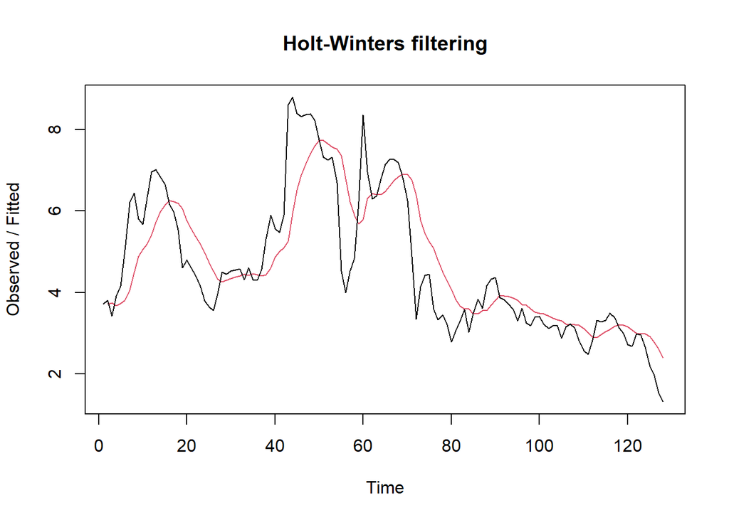

```r
#Cara 2 (fungsi Holtwinter)
ses1<- HoltWinters(train_data.ts, gamma = FALSE, beta = FALSE, alpha = 0.2)
plot(ses1)
```

```r
#ramalan
ramalan1<- forecast(ses1, h=32)
ramalan1
```

```
##     Point Forecast     Lo 80    Hi 80       Lo 95    Hi 95
## 129       2.182154 0.9124247 3.451884  0.24027045 4.124038
## 130       2.182154 0.8872791 3.477030  0.20181357 4.162495
## 131       2.182154 0.8626126 3.501696  0.16408940 4.200219
## 132       2.182154 0.8383988 3.525910  0.12705759 4.237251
## 133       2.182154 0.8146137 3.549695  0.09068137 4.273627
## 134       2.182154 0.7912352 3.573074  0.05492711 4.309382
## 135       2.182154 0.7682433 3.596066  0.01976394 4.344545
## 136       2.182154 0.7456193 3.618690 -0.01483650 4.379145
## 137       2.182154 0.7233461 3.640963 -0.04890041 4.413209
## 138       2.182154 0.7014079 3.662901 -0.08245199 4.446761
## 139       2.182154 0.6797900 3.684519 -0.11551368 4.479823
## 140       2.182154 0.6584788 3.705830 -0.14810635 4.512415
## 141       2.182154 0.6374616 3.726847 -0.18024939 4.544558
## 142       2.182154 0.6167265 3.747582 -0.21196093 4.576270
```

[output cut: 18 more lines]

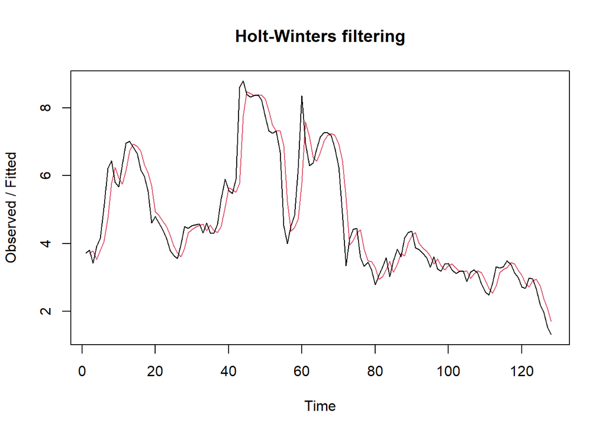

```r
ses2<- HoltWinters(train_data.ts, gamma = FALSE, beta = FALSE, alpha = 0.7)
plot(ses2)
```

```r
#ramalan
ramalan2<- forecast(ses2, h=32)
ramalan2
```

```
##     Point Forecast       Lo 80    Hi 80       Lo 95    Hi 95
## 129       1.434561  0.62258024 2.246542  0.19274356 2.676379
## 130       1.434561  0.44341216 2.425710 -0.08127038 2.950392
## 131       1.434561  0.29200277 2.577119 -0.31283105 3.181953
## 132       1.434561  0.15843303 2.710689 -0.51710833 3.386230
## 133       1.434561  0.03757644 2.831546 -0.70194255 3.571065
## 134       1.434561 -0.07362637 2.942748 -0.87201257 3.741135
## 135       1.434561 -0.17717484 3.046297 -1.03037629 3.899498
## 136       1.434561 -0.27446086 3.143583 -1.17916241 4.048285
## 137       1.434561 -0.36649952 3.235622 -1.31992340 4.189046
## 138       1.434561 -0.45405815 3.323180 -1.45383276 4.322955
## 139       1.434561 -0.53773349 3.406856 -1.58180316 4.450925
## 140       1.434561 -0.61800053 3.487123 -1.70456101 4.573683
## 141       1.434561 -0.69524466 3.564367 -1.82269570 4.691818
## 142       1.434561 -0.76978367 3.638906 -1.93669328 4.805815
```

[output cut: 18 more lines]

Fungsi HoltWinters memiliki argumen yang sama dengan fungsi ses() . Argumen-argumen kedua fungsi dapat dilihat lebih lanjut dengan ?ses() atau ?HoltWinters .

Nilai parameter $\alpha$ dari kedua fungsi dapat dioptimalkan menyesuaikan dari error-nya paling minimumnya. Caranya adalah dengan membuat parameter $\alpha =$ NULL .

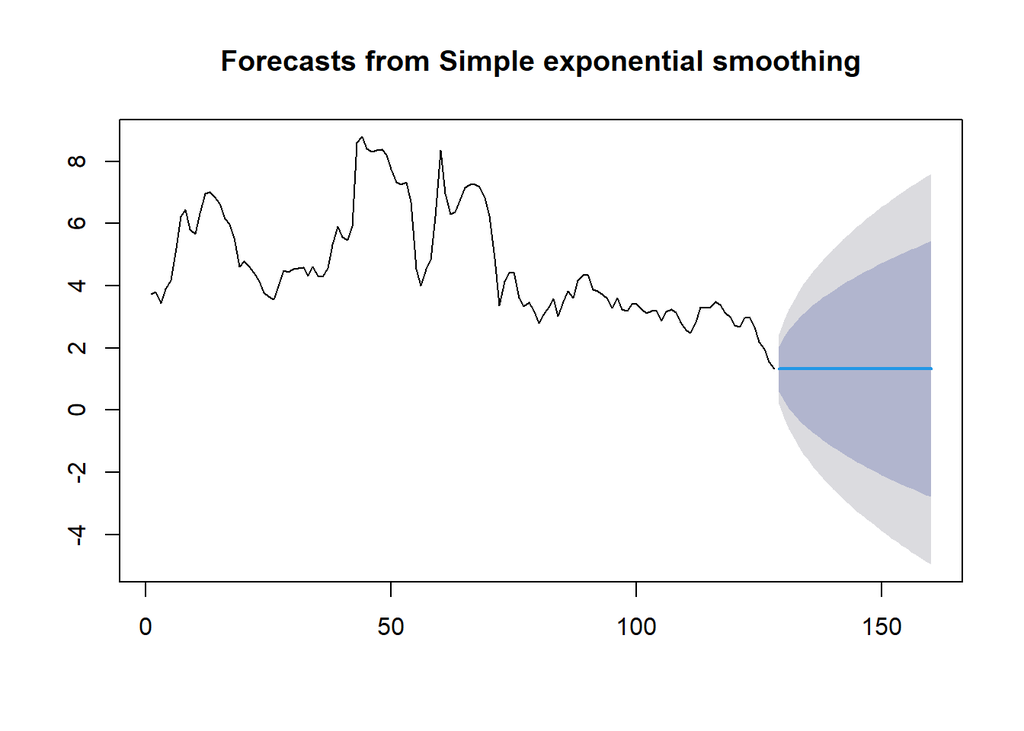

```r
#SES
ses.opt <- ses(train_data.ts, h = 32, alpha = NULL)
plot(ses.opt)
```

```r
ses.opt
```

```
##     Point Forecast      Lo 80    Hi 80      Lo 95    Hi 95
## 129       1.320022  0.5927902 2.047254  0.2078169 2.432227
## 130       1.320022  0.2916123 2.348432 -0.2527949 2.892839
## 131       1.320022  0.0605035 2.579541 -0.6062453 3.246289
## 132       1.320022 -0.1343326 2.774377 -0.9042214 3.544265
## 133       1.320022 -0.3059877 2.946032 -1.1667453 3.806789
## 134       1.320022 -0.4611765 3.101220 -1.4040860 4.044130
## 135       1.320022 -0.6038876 3.243932 -1.6223439 4.262388
## 136       1.320022 -0.7367202 3.376764 -1.8254938 4.465538
## 137       1.320022 -0.8614795 3.501524 -2.0162967 4.656341
## 138       1.320022 -0.9794800 3.619524 -2.1967628 4.836807
## 139       1.320022 -1.0917138 3.731758 -2.3684097 5.008454
## 140       1.320022 -1.1989520 3.838996 -2.5324163 5.172460
## 141       1.320022 -1.3018076 3.941852 -2.6897203 5.329764
## 142       1.320022 -1.4007777 4.040822 -2.8410820 5.481126
```

[output cut: 18 more lines]

```r
#Lamda Optimum Holt Winter
sesopt<- HoltWinters(train_data.ts, gamma = FALSE, beta = FALSE,alpha = NULL)
sesopt
```

```
## Holt-Winters exponential smoothing without trend and without seasonal component.
##
## Call:
## HoltWinters(x = train_data.ts, alpha = NULL, beta = FALSE, gamma = FALSE)
##
## Smoothing parameters:
##  alpha: 0.9999213
##  beta : FALSE
##  gamma: FALSE
##
## Coefficients:
##       [,1]
## a 1.320017
```

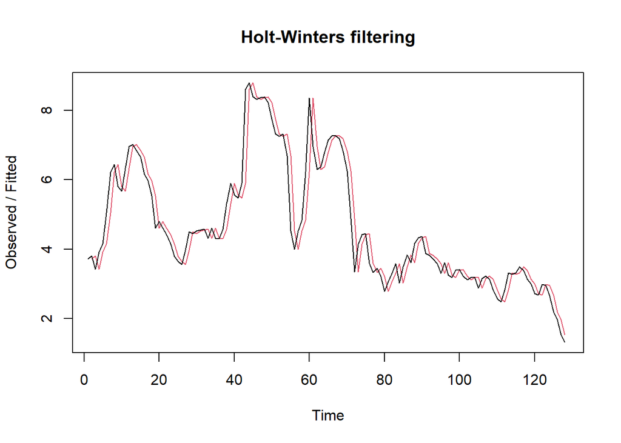

```r
plot(sesopt)
```

```r
#ramalan
ramalanopt<- forecast(sesopt, h=32)
ramalanopt
```

```
##     Point Forecast       Lo 80    Hi 80      Lo 95    Hi 95
## 129       1.320017  0.59319642 2.046838  0.2084407 2.431594
## 130       1.320017  0.29217782 2.347857 -0.2519276 2.891962
## 131       1.320017  0.06119268 2.578842 -0.6051888 3.245223
## 132       1.320017 -0.13353863 2.773573 -0.9030047 3.543039
## 133       1.320017 -0.30510124 2.945136 -1.1653870 3.805422
## 134       1.320017 -0.46020620 3.100241 -1.4025996 4.042634
## 135       1.320017 -0.60284024 3.242875 -1.6207396 4.260774
## 136       1.320017 -0.73560099 3.375636 -1.8237796 4.463814
## 137       1.320017 -0.86029277 3.500327 -2.0144792 4.654514
## 138       1.320017 -0.97822929 3.618264 -2.1948476 4.834882
## 139       1.320017 -1.09040234 3.730437 -2.3664014 5.006436
## 140       1.320017 -1.19758240 3.837617 -2.5303192 5.170354
## 141       1.320017 -1.30038223 3.940417 -2.6875380 5.327573
## 142       1.320017 -1.39929863 4.039333 -2.8388175 5.478852
```

[output cut: 18 more lines]

Setelah dilakukan peramalan, akan dilakukan perhitungan keakuratan hasil peramalan. Perhitungan akurasi ini dilakukan baik pada data latih dan data uji.

###Akurasi Data Latih

Perhitungan akurasi data dapat dilakukan dengan cara langsung maupun manual. Secara langsung, nilai akurasi dapat diambil dari objek yang tersimpan pada hasil SES, yaitu sum of squared errors (SSE). Nilai akurasi lain dapat dihitung pula dari nilai SSE tersebut.

```r
#Keakuratan Metode
#Pada data training
SSE1<-ses1$SSE
MSE1<-ses1$SSE/length(train_data.ts)
RMSE1<-sqrt(MSE1)

akurasi1 <- matrix(c(SSE1,MSE1,RMSE1))
row.names(akurasi1)<- c("SSE", "MSE", "RMSE")
colnames(akurasi1) <- c("Akurasi lamda=0.2")
akurasi1
```

```
##      Akurasi lamda=0.2
## SSE        124.1516511
## MSE          0.9699348
## RMSE         0.9848527
```

```r
SSE2<-ses2$SSE
MSE2<-ses2$SSE/length(train_data.ts)
RMSE2<-sqrt(MSE2)

akurasi2 <- matrix(c(SSE2,MSE2,RMSE2))
row.names(akurasi2)<- c("SSE", "MSE", "RMSE")
colnames(akurasi2) <- c("Akurasi lamda=0.7")
akurasi2
```

```
##      Akurasi lamda=0.7
## SSE         50.6652255
## MSE          0.3958221
## RMSE         0.6291439
```

```r
#Cara Manual
fitted1<-ramalan1$fitted
sisaan1<-ramalan1$residuals
head(sisaan1)
```

```
## Time Series:
## Start = 1
## End = 6
## Frequency = 1
## [1]        NA  0.090000 -0.308000  0.233600  0.436880  1.239504
```

```r
resid1<-training_data$Inflasi-ramalan1$fitted
head(resid1)
```

```
## Time Series:
## Start = 1
## End = 6
## Frequency = 1
## [1]        NA  0.090000 -0.308000  0.233600  0.436880  1.239504
```

```r
#Cara Manual
SSE.1=sum(sisaan1[2:length(train_data.ts)]^2)
SSE.1
```

```
## [1] 124.1517
```

```r
MSE.1 = SSE.1/length(train_data.ts)
MSE.1
```

```
## [1] 0.9699348
```

```r
MAPE.1 = sum(abs(sisaan1[2:length(train_data.ts)]/train_data.ts[2:length(train_data.ts)])*
               100)/length(train_data.ts)
MAPE.1
```

```
## [1] 15.96745
```

```r
akurasi.1 <- matrix(c(SSE.1,MSE.1,MAPE.1))
row.names(akurasi.1)<- c("SSE", "MSE", "MAPE")
colnames(akurasi.1) <- c("Akurasi lamda=0.2")
akurasi.1
```

```
##      Akurasi lamda=0.2
## SSE        124.1516511
## MSE          0.9699348
## MAPE        15.9674519
```

```r
fitted2<-ramalan2$fitted
sisaan2<-ramalan2$residuals
head(sisaan2)
```

```
## Time Series:
## Start = 1
## End = 6
## Frequency = 1
## [1]        NA  0.090000 -0.353000  0.374100  0.362230  0.998669
```

```r
resid2<-training_data$Inflasi-ramalan2$fitted
head(resid2)
```

```
## Time Series:
## Start = 1
## End = 6
## Frequency = 1
## [1]        NA  0.090000 -0.353000  0.374100  0.362230  0.998669
```

```r
SSE.2=sum(sisaan2[2:length(train_data.ts)]^2)
SSE.2
```

```
## [1] 50.66523
```

```r
MSE.2 = SSE.2/length(train_data.ts)
MSE.2
```

```
## [1] 0.3958221
```

```r
MAPE.2 = sum(abs(sisaan2[2:length(train_data.ts)]/train_data.ts[2:length(train_data.ts)])*
               100)/length(train_data.ts)
MAPE.2
```

```
## [1] 9.314015
```

```r
akurasi.2 <- matrix(c(SSE.2,MSE.2,MAPE.2))
row.names(akurasi.2)<- c("SSE", "MSE", "MAPE")
colnames(akurasi.2) <- c("Akurasi lamda=0.7")
akurasi.2
```

```
##      Akurasi lamda=0.7
## SSE         50.6652255
## MSE          0.3958221
## MAPE         9.3140152
```

###Akurasi Data Uji

Akurasi data uji dapat dihitung dengan cara yang hampir sama dengan perhitungan akurasi data latih

```r
selisih1<-ramalan1$mean-testing_data$Inflasi
SSEtesting1<-sum(selisih1^2)
MSEtesting1<-SSEtesting1/length(testing_data)

selisih2<-ramalan2$mean-testing_data$Inflasi
SSEtesting2<-sum(selisih2^2)
MSEtesting2<-SSEtesting2/length(testing_data)

selisihopt<-ramalanopt$mean-testing_data$Inflasi
SSEtestingopt<-sum(selisihopt^2)
MSEtestingopt<-SSEtestingopt/length(testing_data)

akurasitesting1 <- matrix(c(SSEtesting1,SSEtesting2,SSEtestingopt))
row.names(akurasitesting1)<- c("SSE1", "SSE2", "SSEopt")
akurasitesting1
```

```
##            [,1]
## SSE1   110.0223
## SSE2   166.0956
## SSEopt 177.8471
```

```r
akurasitesting2 <- matrix(c(MSEtesting1,MSEtesting2,MSEtestingopt))
row.names(akurasitesting2)<- c("MSE1", "MSE2", "MSEopt")
akurasitesting2
```

```
##            [,1]
## MSE1   55.01115
## MSE2   83.04781
## MSEopt 88.92353
```

Selain dengan cara di atas, perhitungan nilai akurasi dapat menggunakan fungsi accuracy() dari package forecast . Penggunaannya yaitu dengan menuliskan accuracy(hasil ramalan, kondisi aktual) . Contohnya adalah sebagai berikut.

```r
#cara lain
accuracy(ramalanopt,testing_data$Inflasi)
```

```
##                       ME      RMSE       MAE       MPE      MAPE     MASE
## Training set -0.01889899 0.5652202 0.3699331 -1.460823  8.303444 1.000032
## Test set      1.66029517 2.3574818 1.6602952 40.408512 40.408512 4.488239
##                   ACF1
## Training set 0.2772466
## Test set            NA
```